# AMSTROM: Preprocessing and Analysis Pipeline

AMSTROM: Preprocessing and Analysis Pipeline

Morgan Virolan

Python-R-Git course, Denis Mottet

Faculty of Sports and Health Sciences (UFR STAPS)  
MSc in Engineering and Ergonomics of Physical Activity  
Université de Montpellier, Academic Year 2025-2026

https://github.com/MorganVir/AMSTROM_CAMPAIGN

# AMSTROM: Preprocessing and Analysis Pipeline

## 1. Introduction

Muscular fatigue is a progressive reduction in force production during sustained or repeated contractions, with documented consequences for sport performance, rehabilitation, and occupational safety (Enoka & Duchateau, 2008; Behrens et al., 2023).

The AMSTROM project studies this process in the quadriceps using a multimodal approach. Three modalities record continuously and simultaneously throughout the session: sEMG captures neuromuscular activation but misses the metabolic dimension of fatigue (Praagman et al., 2003); NIRS fills that gap, tracking oxidative metabolism through tissue oxygenation (Barstow, 2019; Perrey et al., 2024); BIA tracks fluid shifts and tissue changes that accompany repeated contractions (Sanchez et al., 2017). A fourth device, the MyotonPRO, captures intermittent snapshots of passive muscle mechanical properties (tone, stiffness, and damping) at rest intervals between protocol phases. No single modality captures all dimensions of the fatigue process. Participants performed a protocol on an isokinetic dynamometer including MVC trials, submaximal contractions at several force levels, and a repeated contraction task designed to progressively fatigue the quadriceps.

I expect each modality’s indicators to correlate with the dynamic evolution of muscle force output, with distinct kinetics between them.

**Engineering problem.** These sensors record at 2 to 2148 Hz, in different file formats, with independent internal clocks. Before any analysis, the signals need to be synchronized, labeled, and restructured. That is what this pipeline does.

## 2. Overview

The project runs as a two-stage pipeline, illustrated in Figure 0. Python handles raw data: loading, synchronization, event labeling, and export to Parquet. R handles feature extraction and exploratory analysis, split across two scripts: `main.Rmd` runs per participant (filtering, RMS/MDF extraction), and `cohort_analysis.Rmd` pools the results across participants for cohort-level trend analysis.

[figure not shown]

Figure 0. Two-stage pipeline. The Jupyter notebook (main.ipynb) orchestrates each step, passing a shared CTX dictionary and exposing per-step force_recompute flags. Python scripts (_01_ to _08_) preprocess each modality and write Parquet caches. R reads those exports in two phases: `main.Rmd` runs per participant (filtering, feature extraction); `cohort_analysis.Rmd` pools all runs for cohort-level analysis.

## 3. Experimental data

| Signal | Device | Approx. sampling rate |
| --- | --- | --- |
| sEMG | Delsys Trigno | ~2148 Hz |
| Torque | Biodex dynamometer | ~518 Hz |
| NIRS | PortaLite | ~10 Hz |
| Bio-impedance | LIRMM prototype | ~2 Hz |
| Muscle mechanics (Myoton) | MyotonPRO | discrete (5 taps/test) |

Individual EMG files reach several hundred megabytes. The full dataset exceeds 15 GB, which ruled out any approach that kept raw data in memory throughout the pipeline.

A one-participant sample dataset for testing the pipeline is available at: [Google Drive — AMSTROM sample data](https://drive.google.com/drive/folders/10iPFnAbGn_sLfF1ugzaStwE31-_hLbCB?usp=sharing).

## 4. Preprocessing pipeline

### 4.1 Data management

Data management follows the EuroMov DHM Data Management Plan. Each participant gets a pseudonymized code in the format XXXNnPp (three random digits plus two-letter abbreviations of surname and first name). Nominal identity stays in physical records and is never digitized. Recordings are stored on my laptop, a USB drive, and the LIRMM server.

Metadata collected per session includes date of birth, sex, height, mass, dominant side, and sensor configuration. The study protocol was validated by the EuroMov IRB and the University of Montpellier ethics committee (avis consultatif n° UM 2025-030).

### 4.2 Architecture and caching

Steps are either fully automatic (deterministic) or semi-automatic. For semi-automatic steps, the script produces a first-pass result and a QC plot. I review it, adjust parameter knobs, and commit the validated result to a Parquet cache file in a separate notebook cell. This two-phase design came out of a painful early experience running everything inline in a single notebook: variables bled between steps, debugging required rerunning the whole session, and modifying one step broke the rest without warning.

Large DataFrames are mutated in place rather than versioned (no `df`, `df_filtered`, `df_clean` chains). This saves RAM on an 8 GB laptop but requires explicit column-presence checks at each step to catch errors early.

Each script exposes a `force_recompute` flag. When `False` and a valid Parquet cache exists, the script loads the cache and returns immediately. When `True`, it deletes the cache and reruns from raw data. Tuning a sync parameter in step `_06_` therefore costs only that one step, not the full 15 GB pipeline. The flag is set explicitly per cell in the notebook, which makes the recompute decision visible rather than hidden inside script internals.

Version control runs through GitHub. I branched on each major version (this submission is V3) and after each significant functional addition, once tested. It also synced the project across two machines. Team features were not used: solo project, coding side.

### 4.3 Participant selection

Script `_01_` loads the Excel participant sheet for the current `RUN_ID`. Not all cells were filled consistently in the source data (e.g., “85 kg” instead of a plain number), so the script parses fields with regex to extract clean numeric values. The cleaned metadata is stored in `CTX` and used by every downstream script.

### 4.4 Master timeline construction

The Delsys EMG file format varies between sessions because the system does not always initialize in the same state. The import script detects the correct data onset dynamically instead of assuming a fixed header offset.

Once loaded, the pipeline estimates the median EMG sampling interval and reconstructs a regular time grid. Each sample receives an integer index (`time_index`) and a relative time in seconds (`time_ref_s`). This grid acts as controlled downsampling: only indexed samples needed for downstream analysis are kept, and the raw signal is discarded after mapping. A reconstructed regular grid also handles the jitter in raw device timestamps better than using the originals directly.

### 4.5 Protocol labeling

Three columns are added to the master grid:

- `SEQ`: protocol phase (INIT, WU, REST, MVC_REF, SVC_REF, EX_DYN, EX_STA, MVC_RECOV, END)
- `VC`: binary contraction flag
- `VC_count`: repetition counter, resets at each new sequence

Sequence boundaries are picked manually by clicking on an interactive Matplotlib widget over the torque trace. With 30 participants and a known fixed protocol, building a reliable automatic detector was more work than the manual approach. Picking boundaries takes about two minutes per participant.

Contraction detection within each sequence is automatic: torque rising above a threshold flags a VC. Per-sequence knobs handle variability between participants (missed start cues, extra warmup repetitions). Human validation is required before the result is committed to cache.

Labeling is placed at step 3, after the EMG and torque caches are stable but before the heavier modality imports. This keeps the master grid lean during the iterative QC loop. The SEQ, VC, and VC_count columns are defined to match the LIRMM database schema, so the final Parquet exports can be ingested without any column renaming or reshaping on the database side.

## 5. Integration of additional modalities

After labeling, I import NIRS, BIA, and Myoton data from their respective raw formats and map each to the master grid by nearest-neighbour timestamp matching.

### 5.1 Torque

Torque is loaded during the EMG import step. Raw voltage is converted to Newton-metres using the Biodex calibration parameters. Because torque timestamps are already in seconds, synchronization is a direct nearest-neighbour assignment to `time_index`. Torque drives contraction detection and anchors the lag estimation for both NIRS and BIA.

### 5.2 NIRS

NIRS data comes from the PortaLite as an Oxysoft TXT export. Timestamps are reconstructed from the recording start time and nominal sampling rate (~10 Hz). After nearest-neighbour mapping to the master grid, a temporal lag is estimated from HHb onset dynamics during MVC_REF and applied as an integer `time_index` shift.

### 5.3 BIA

BIA is the main contribution of the project partner, LIRMM. The device is a prototype; files export as Python pickles, which simplified import. Timestamps are reconstructed and mapped to the master grid. A sync lag is estimated during MVC_REF by maximizing the impedance modulus |Z| difference between contraction and rest phases, then applied as an integer shift.

### 5.4 Myoton

The MyotonPRO device measures passive muscle mechanical properties by delivering a brief mechanical impulse and recording the damped oscillation response. Five metrics are captured per measurement: tone frequency (Hz), stiffness (N/m), decrement, relaxation time (ms), and creep. Each test consists of five taps; script `_07_` averages those into per-test means and maps each measurement timestamp to the nearest point in the master grid by nearest-neighbour matching. The result is a sparse table: one row per tap, one row per test average, both carrying the SEQ label of the timepoint they landed on. This lets downstream analysis compare muscle mechanical state across protocol phases without any interpolation into the 2148 Hz master grid.

### 5.5 Synchronization quality control

After all modalities are cached, script `_08_` reloads the Parquet exports and generates multimodal overlay plots. Loading from disk rather than from memory was a hard-won lesson: early in the project, QC figures looked fine while the cached files had not actually been written correctly. Reading from disk guarantees the QC reflects what was exported. These plots were used in team reviews to classify each dataset as usable, questionable, or bad. Figure 1 shows a representative NIRS synchronization QC output for participant 101SaCl.

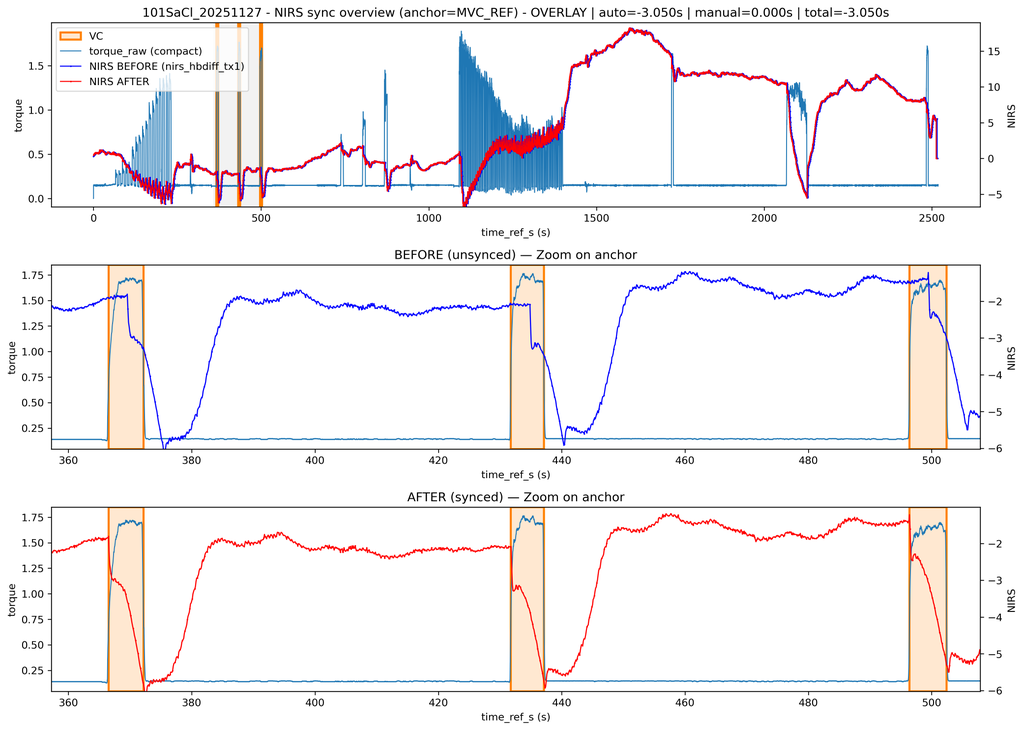

## 6. Signal analysis in R

### 6.1 Loading and filtering

The exported Parquet files are loaded in R using the `arrow` library. The compact per-run exports are small enough for a standard R workflow, unlike the raw EMG files.

Raw EMG is band-pass filtered with a 4th-order Butterworth filter (20-450 Hz). The signal is mean-centred first to remove the DC offset. Zero-phase forward-backward filtering (`filtfilt`) avoids phase distortion, preserving temporal alignment relative to the torque signal.

### 6.2 Feature extraction

`VC` and `VC_count` labels isolate each contraction. Features are computed from the middle one second of each contraction, avoiding the onset and offset transients. Two descriptors per channel per contraction:

- **RMS**: signal amplitude, proxy for motor unit recruitment
- **MDF**: median frequency of the power spectrum, sensitive to fatigue-related conduction velocity changes

This produces a repetition-level feature table across all channels and sequences.

### 6.3 Cohort-level analysis

Feature tables from individual runs are pooled across participants using a shared Parquet schema. The cohort analysis tracks how RMS, MDF, and torque evolve as a function of `VC_count` during EX_DYN and EX_STA. Linear models quantify trends per channel. At this stage I care about validation, not interpretation: consistent trends across participants mean the preprocessing chain works.

## 7. Preliminary results

I completed the EMG and torque analysis. NIRS and BIA are preprocessed and synchronized; cohort-level feature extraction for those two is the next step.

In EX_DYN: torque drops across repetitions, RMS climbs (more motor units recruited as force capacity declines), MDF falls (power spectrum shifts toward lower frequencies as conduction velocity decreases, Moritani et al., 1986; Muceli & Merletti, 2024). The pipeline picks up all three trends consistently across the cohort (Figures 2 and 3).

These are early-stage results. The current pipeline applies no artefact rejection beyond the bandpass filter. Movement artefacts and signal saturation are present in several recordings and will require a dedicated cleaning step before final interpretation.

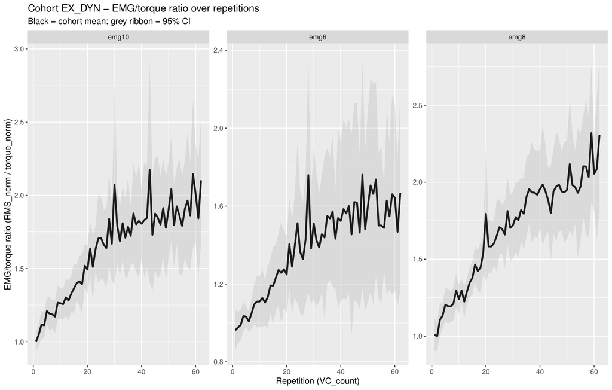

Figure 2. Cohort EX_DYN: EMG/torque ratio over repetitions (n = 10 runs, 95% CI ribbon). Starting at 1, the ratio rises progressively across all three quadriceps channels (emg6, emg8, emg10), showing that more neuromuscular drive is required per unit of torque as the set accumulates.

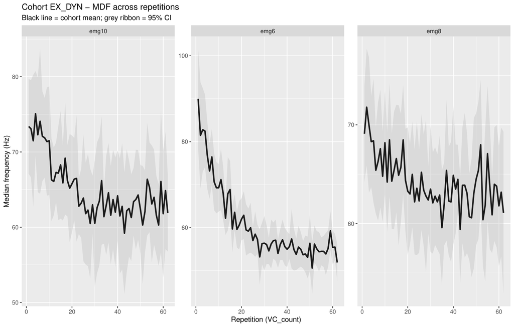

## 8. Discussion

Four independent acquisition systems, four different clocks. Getting them onto a shared time axis was the first real problem. Using the EMG signal as the temporal reference made sense: highest sampling rate, stable enough timestamps to reconstruct a regular grid, and recorded by the same device as torque, which simplified the initial import.

Parquet caching made a 15 GB dataset workable on a student laptop: each validated step writes to disk, so nothing has to be recomputed from scratch. It also means any team member can reload a validated state without touching the raw data.

## 9. Conclusion

I built a working preprocessing and analysis pipeline for a multimodal quadriceps fatigue protocol. It runs on three foundations: a shared EMG-derived time grid, Parquet intermediate caches, and a hybrid of automatic processing and manual validation. Python handles synchronization and labeling; R handles feature extraction and cohort-level analysis.

Cohort-level EMG and torque analysis shows consistent fatigue trends across participants. NIRS and BIA preprocessing is done; cohort-level feature analysis for both is the next step.

## LLM Attribution

LLM use evolved across the project. Early phases: GitHub Copilot (Gemini model) for inline suggestions, light and mostly passive. Then a period of copy-pasting into ChatGPT, functional but slow, with friction at every iteration. More recently I moved to Claude integrated directly into VS Code, context fed through dedicated `.md` files, and agent mode. Productivity jumped. For the downstream R analysis I plan to use it more, while keeping statistical choices and interpretation mine.

## References

Barstow, T. J. (2019). Understanding near infrared spectroscopy and its application to skeletal muscle research. *Journal of Applied Physiology*, 126(5), 1360-1376.

Behrens, M., et al. (2023). Fatigue-related impairments in neuromuscular function. *European Journal of Applied Physiology*.

Enoka, R. M., & Duchateau, J. (2008). Muscle fatigue: what, why and how it influences muscle function. *Journal of Physiology*, 586(1), 11-23.

Moritani, T., et al. (1986). Electromyographic manifestations of muscular fatigue. *Critical Reviews in Physical and Rehabilitation Medicine*.

Muceli, S., & Merletti, R. (2024). Surface EMG signal processing and decomposition. *Journal of Electromyography and Kinesiology*.

Perrey, S., et al. (2024). Muscle near-infrared spectroscopy: current applications and future directions. *Sports Medicine*, 54, 975-996.

Praagman, M., et al. (2003). The relationship between two electromyographic fatigue indicators. *Journal of Electromyography and Kinesiology*, 13(5), 477-485.

Sanchez, B., et al. (2017). Non-invasive assessment of muscle injury using electrical impedance myography. *Muscle & Nerve*, 56(6), E85-E94.